# COGS 108 - Final Project

## Important

- ONE, and only one, member of your group should upload this notebook to TritonED.
- Each member of the group will receive the same grade on this assignment.
- Keep the file name the same: submit the file 'FinalProject.ipynb'.
- Only upload the .ipynb file to TED, do not upload any associted data. Make sure that for cells in which you want graders to see output that these cells have been executed.

## Group Members: Fill in the Student IDs of each group member here

Replace the lines below to list each persons full student ID, ucsd email and full name.

- A12786420 - aln011@ucsd.edu - Alvin Ngo
- A14947178 - jmcdouga@ucsd.edu - James Ian McDougall Jr.
- A12588001 - chh145@ucsd.edu - Chen Huang

# Part 0 - Importing the required packages

```python
import pandas as pd # for use of dataframes
import numpy as np
import matplotlib.pyplot as plt # for plotting graphs
import seaborn as sns
import statsmodels.api as sm # for fitting an OLS model
import scipy.stats as stats # for access to tests for normal distribution
import statsmodels.formula.api as smf
from scipy.stats import ttest_ind, normaltest # for access to t tests, normal test
%matplotlib inline
```

# Part 1 - Introduction and Background

#### Introduction

Chicago, otherwise known as 'The Windy City', has some of the worst crime rates in America. Some of this has to do with statitical flukes; it is the third largest city in the U.S., which makes any type of criminal activity more easily reportable. However, most people wouldn't argue over the real danger you are in when you go to some of the worse off areas of Chicago.

We wanted to analyze the crime rates in Chicago in some way in order to assist people in the city in understanding what problems exist and where they are happening.

#### Research Question

"Does the district a crime is committed in or type of crime more closely predict whether an arrest was made".

The answers derived from the answer to this question could spawn further analysis, e.g.:

1. If a particular crime is more likely to result in an arrest in one district over the other, why is that? Is it the police in that district? Is it the citizens? Or is it the geography?
2. If the type of crime affects whether an arrest is made, does that mean that we are more afraid of certain crimes over others? Is this a valid fear?

#### Hypothesis

**We hypothesize that district will be more predictive of arrest than crime type.** We think that the district where the crime occurs will strongly affect the amount of police and by extension the amount of arrests.

# Part 2 - Data Description

We are using this dataset: https://www.kaggle.com/chicago/chicago-crime

This is chicago crime data from 2001 to present. It represents all *reported* instances of crime, and whether or not an arrest has been made since the data was last released. Each row represents a crime, except for multiple homicides, for which there is a different row for each victim of the crime.

Here are some basic stats:

```python
crime = pd.read_csv('/Users/alvin/Downloads/Crimes_-_2001_to_present.csv')
```

```python
crime.head()
```

|  | ID | Case Number | Date | Block | IUCR | Primary Type | Description | Location Description | Arrest | Domestic | ... | Ward | Community Area | FBI Code | X Coordinate | Y Coordinate | Year | Updated On | Latitude | Longitude | Location |
| --- | --- | --- | --- | --- | --- | --- | --- | --- | --- | --- | --- | --- | --- | --- | --- | --- | --- | --- | --- | --- | --- |
| 0 | 7956475 | HT188097 | 3/4/2011 10:52 | 025XX S KILDARE AVE | 554 | ASSAULT | AGG PO HANDS NO/MIN INJURY | SCHOOL, PUBLIC, BUILDING | True | False | ... | 22.0 | 30.0 | 08A | 1148345.0 | 1886897.0 | 2011 | 2/10/2018 15:50 | 41.845586 | -87.731082 | (41.84558589, -87.731082337) |
| 1 | 7956476 | HT185132 | 3/4/2011 12:00 | 024XX W 45TH PL | 1150 | DECEPTIVE PRACTICE | CREDIT CARD FRAUD | RESIDENCE | False | False | ... | 12.0 | 58.0 | 11 | 1160803.0 | 1874437.0 | 2011 | 2/10/2018 15:50 | 41.811145 | -87.685707 | (41.811145384, -87.685707211) |
| 2 | 7956477 | HT187881 | 3/4/2011 9:00 | 023XX N CLYBOURN AVE | 1310 | CRIMINAL DAMAGE | TO PROPERTY | RESIDENCE | False | False | ... | 32.0 | 7.0 | 14 | 1165097.0 | 1915872.0 | 2011 | 2/10/2018 15:50 | 41.924757 | -87.668781 | (41.924756753, -87.668780552) |
| 3 | 7956479 | HT187939 | 3/3/2011 8:00 | 003XX W 100TH ST | 890 | THEFT | FROM BUILDING | RESIDENTIAL YARD (FRONT/BACK) | False | False | ... | 9.0 | 49.0 | 6 | 1175827.0 | 1838618.0 | 2011 | 2/10/2018 15:50 | 41.712530 | -87.631672 | (41.712529985, -87.631672138) |
| 4 | 7956480 | HT187986 | 3/4/2011 10:35 | 065XX W BRYN MAWR AVE | 460 | BATTERY | SIMPLE | SCHOOL, PUBLIC, BUILDING | True | False | ... | 41.0 | 10.0 | 08B | 1131583.0 | 1936817.0 | 2011 | 2/10/2018 15:50 | 41.982879 | -87.791441 | (41.98287878, -87.791440835) |

5 rows × 22 columns

```python
crime.describe()
```

|  | ID | Beat | District | Ward | Community Area | X Coordinate | Y Coordinate | Year | Latitude | Longitude |
| --- | --- | --- | --- | --- | --- | --- | --- | --- | --- | --- |
| count | 6.808630e+05 | 680863.000000 | 680863.000000 | 676588.000000 | 676455.000000 | 6.776110e+05 | 6.776110e+05 | 680863.000000 | 677611.000000 | 677611.000000 |
| mean | 8.567042e+06 | 1175.978743 | 11.308450 | 22.770445 | 37.770586 | 1.164485e+06 | 1.885306e+06 | 2011.814654 | 41.840877 | -87.671938 |
| std | 8.225777e+05 | 698.030896 | 6.916479 | 13.753105 | 21.547608 | 1.653952e+04 | 3.170872e+04 | 1.349423 | 0.087219 | 0.060123 |
| min | 2.755000e+03 | 111.000000 | 1.000000 | 1.000000 | 0.000000 | 0.000000e+00 | 0.000000e+00 | 2001.000000 | 36.619446 | -91.686566 |
| 25% | 8.217138e+06 | 621.000000 | 6.000000 | 10.000000 | 23.000000 | 1.152671e+06 | 1.858662e+06 | 2011.000000 | 41.767524 | -87.714810 |
| 50% | 8.750056e+06 | 1031.000000 | 10.000000 | 22.000000 | 32.000000 | 1.165933e+06 | 1.890256e+06 | 2012.000000 | 41.854636 | -87.666379 |
| 75% | 9.032286e+06 | 1723.000000 | 17.000000 | 34.000000 | 58.000000 | 1.176352e+06 | 1.909012e+06 | 2013.000000 | 41.906133 | -87.628220 |
| max | 1.050916e+07 | 2535.000000 | 31.000000 | 50.000000 | 77.000000 | 1.205119e+06 | 1.951573e+06 | 2016.000000 | 42.022710 | -87.524529 |

```python
print('Total Number of Crimes:\t\t\t{0}'.format(len(crime)))
print('Total number of Unique Districts:\t{0}'.format(len(crime['District'].unique())))
```

```
Total Number of Crimes:			680863
Total number of Unique Districts:	23
```

# Part 3 - Data Cleaning and Preprocessing

This data is fairly clean, because it is maintained by the Chicago Police Department, which has high organizational standards. There aren't very many invalid crimes or unknowns.

To clean the data, we will do the following (not necessarily in order):

1. Drop useless columns and columns that invade privacy
2. Standardize the location description
3. Standardize the crime type to get rid of the uppercase, standardize the non-criminal type
4. Remove NaN values

```python
# first, drop the location description column and community area column because of privacy concerns
crime = crime.drop(['Location Description', 'Block', 'Community Area','Latitude', 'Beat', 'Ward','Longitude','X Coordinate','Y Coordinate','Location','Ward'],axis=1)
```

```python
crime.head()
```

|  | ID | Case Number | Date | IUCR | Primary Type | Description | Arrest | Domestic | District | FBI Code | Year | Updated On |
| --- | --- | --- | --- | --- | --- | --- | --- | --- | --- | --- | --- | --- |
| 0 | 7956475 | HT188097 | 3/4/2011 10:52 | 554 | ASSAULT | AGG PO HANDS NO/MIN INJURY | True | False | 10 | 08A | 2011 | 2/10/2018 15:50 |
| 1 | 7956476 | HT185132 | 3/4/2011 12:00 | 1150 | DECEPTIVE PRACTICE | CREDIT CARD FRAUD | False | False | 9 | 11 | 2011 | 2/10/2018 15:50 |
| 2 | 7956477 | HT187881 | 3/4/2011 9:00 | 1310 | CRIMINAL DAMAGE | TO PROPERTY | False | False | 18 | 14 | 2011 | 2/10/2018 15:50 |
| 3 | 7956479 | HT187939 | 3/3/2011 8:00 | 890 | THEFT | FROM BUILDING | False | False | 5 | 6 | 2011 | 2/10/2018 15:50 |
| 4 | 7956480 | HT187986 | 3/4/2011 10:35 | 460 | BATTERY | SIMPLE | True | False | 16 | 08B | 2011 | 2/10/2018 15:50 |

```python
"""
    Author: James McDougall
    Param: string - is the string which is the name of the Primary Type
    Returns: a variable of type str which is lower case and represents  a more standardized type
"""
def standardize_primary_type(string):
    # compile all non-criminal offenses into on label
    if string == 'NON-CRIMINAL (SUBJECT SPECIFIED)' or string == 'NON - CRIMINAL' or string == 'NON-CRIMINAL':
        return 'non-criminal'
    if string == 'OTHER OFFENSE':
        return 'other'
    # rename crim sexual assault to just sexual assault to make it easier to read
    if string == 'CRIM SEXUAL ASSAULT':
        return 'sexual assault'
    else:
        # everything else, make sure to lowercase it so we don't have to use caps lock lol
        return string.lower()
```

```python
to_drop = crime[ crime['District'].isnull()]
print('Number of rows to drop with NaN district: ' + str(len(to_drop)))
crime = crime.drop(to_drop.index,axis=0)

to_drop = crime[crime['Primary Type'].isnull()]
print('Number of row to drop with NaN Primary Type: ' + str(len(to_drop)))
crime = crime.drop(to_drop.index,axis=0)
```

```
Number of rows to drop with NaN district: 0
Number of row to drop with NaN Primary Type: 0
```

```python
crime['Type'] = crime['Primary Type'].apply(standardize_primary_type)
crime['District'] = crime['District'].astype(str)

def arrest_to_int(string):
    if string == True:
        return 1
    elif string == False:
        return 0
crime['Arrest'] = crime['Arrest'].apply(arrest_to_int)
```

Additionally, we must drop all rows that are in district 31 because this district is not on the main chicago police page, so it is either nonexistant or far enough away from the main Chicago city to not be relevant to our analysis.

```python
crime = crime[crime['District'] != '31']
assert '31' not in crime['District'].unique()
```

```python
crime.head()
```

|  | ID | Case Number | Date | IUCR | Primary Type | Description | Arrest | Domestic | District | FBI Code | Year | Updated On | Type |
| --- | --- | --- | --- | --- | --- | --- | --- | --- | --- | --- | --- | --- | --- |
| 0 | 7956475 | HT188097 | 3/4/2011 10:52 | 554 | ASSAULT | AGG PO HANDS NO/MIN INJURY | 1 | False | 10 | 08A | 2011 | 2/10/2018 15:50 | assault |
| 1 | 7956476 | HT185132 | 3/4/2011 12:00 | 1150 | DECEPTIVE PRACTICE | CREDIT CARD FRAUD | 0 | False | 9 | 11 | 2011 | 2/10/2018 15:50 | deceptive practice |
| 2 | 7956477 | HT187881 | 3/4/2011 9:00 | 1310 | CRIMINAL DAMAGE | TO PROPERTY | 0 | False | 18 | 14 | 2011 | 2/10/2018 15:50 | criminal damage |
| 3 | 7956479 | HT187939 | 3/3/2011 8:00 | 890 | THEFT | FROM BUILDING | 0 | False | 5 | 6 | 2011 | 2/10/2018 15:50 | theft |
| 4 | 7956480 | HT187986 | 3/4/2011 10:35 | 460 | BATTERY | SIMPLE | 1 | False | 16 | 08B | 2011 | 2/10/2018 15:50 | battery |

# Part 4 - Data Visualization

First, let's take a look at the data that we have immediately at our hands by seeing the graph of how many of each type of crimes have been reported to and documented by the Chicago Police Department.

```
<BarContainer object of 29 artists>
```

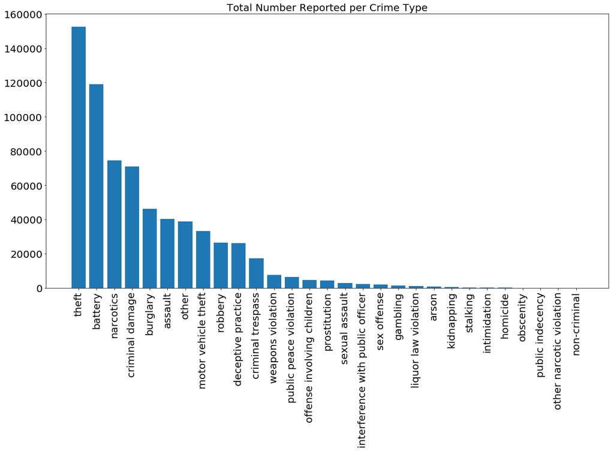

```python
plt.figure(figsize=(20,10))
crimeType = plt.bar(crime.Type.value_counts().index, crime.Type.value_counts())
plt.title('Total Number Reported per Crime Type', fontsize='20')
plt.xticks(rotation='vertical')
plt.tick_params(labelsize=20)
crimeType
```

From the above graph, we can see that certain crime types are reported and/or occur much more frequently than others (the top 3 being theft, battery, and narcotics). Now that we can see which crimes are reported the most, let's dive deeper and see how many total crimes are reported in each district.

```python
districts = crime['District'].unique()
district_cache = {}
arrest_cache = {}
ratio_cache = {}
for district in districts:
    district_cache[district] = len(crime[ crime['District'] == district ]) #gets total num of crimes in each district
    arrest_cache[district] = len(crime[ (crime['Arrest'] == True) & (crime['District'] == district)]) #gets total num of arrests per district
    ratio_cache[district] = arrest_cache[district] / district_cache[district] #gets the ratio of arrests per crime in each district
print(district_cache)
print(arrest_cache)
print(ratio_cache)
```

[output not shown]

```python
districtsTotalCrime = pd.DataFrame.from_dict(district_cache, orient='index')
districtsTotalCrime.columns = ['Total Crimes Reported']
districtsTotalCrime.index.name = 'District Number'
districtsTotalCrime.head()
```

| District Number | Total Crimes Reported |
| --- | --- |
| 10 | 30448 |
| 9 | 34569 |
| 18 | 28690 |
| 5 | 30903 |
| 16 | 22599 |

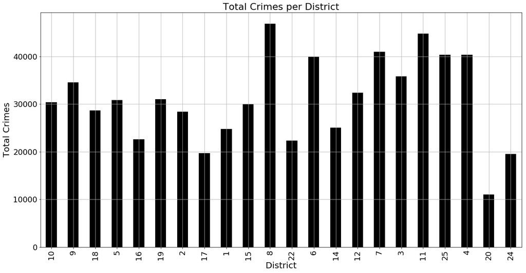

```python
DTCchart = districtsTotalCrime.plot(kind='bar', grid=True, figsize=(20,10), legend=False, color='k')
DTCchart.set_title('Total Crimes per District', fontsize=22)
DTCchart.set_xlabel('District', fontsize=20)
DTCchart.set_ylabel('Total Crimes', fontsize=20)
DTCchart.tick_params(labelsize=18)
DTCchart
```

```python
districtsRatio = pd.DataFrame.from_dict(ratio_cache, orient='index')
districtsRatio.columns = ['Arrest to Crime Ratio']
districtsRatio.index.name = 'District Number'
districtsRatio.head()
```

| District Number | Arrest to Crime Ratio |
| --- | --- |
| 10 | 0.328330 |
| 9 | 0.291909 |
| 18 | 0.246950 |
| 5 | 0.283176 |
| 16 | 0.184389 |

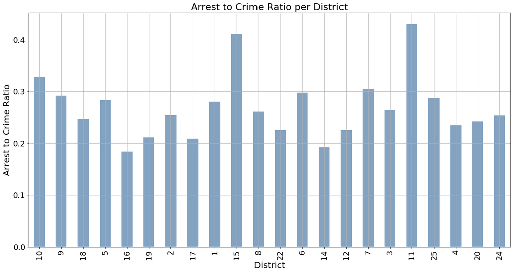

```python
ratioChart = districtsRatio.plot(kind='bar', grid=True, figsize=(20,10), legend=False, color=(0.2, 0.4, 0.6, 0.6))
ratioChart.set_title('Arrest to Crime Ratio per District', fontsize=22)
ratioChart.set_xlabel('District', fontsize=20)
ratioChart.set_ylabel('Arrest to Crime Ratio', fontsize=20)
ratioChart.tick_params(labelsize=18)
ratioChart
```

With this new found info, let's finish out our Data Visualization section by focusing in on the top 3 Crime types (Theft, Battery, and Narcotics) and ploting their arrest to report ratio in each district to compare and utilize in our later Data Analysis section.

To do this, we basically got the number of reports for each crime, the number of arrests made for each crime, and divided the number of arrests over the number of reports to get the final ratio. We ended up doing this for each district, which allowed us to create 3 separate bar graphs to visualize our data.

```python
crime['Primary Type'].value_counts().nlargest(3)
```

```
THEFT        152481
BATTERY      118891
NARCOTICS     74629
Name: Primary Type, dtype: int64
```

```python
dist_pred_arrest = pd.DataFrame()
for district in districts:
    arrest_occurred = crime[crime['Arrest'] == True]

    dist_pred_arrest.loc[district, 'Reported Theft'] = len(crime[(crime['Primary Type'] == 'THEFT') & (crime['District'] == district)])
    dist_pred_arrest.loc[district,'Theft w/ Arrest Made'] = len(arrest_occurred[(arrest_occurred['Primary Type'] == 'THEFT') & (arrest_occurred['District'] == district)])
    dist_pred_arrest.loc[district,'Theft Arrest Rate'] = dist_pred_arrest.loc[district,'Theft w/ Arrest Made'] / dist_pred_arrest.loc[district,'Reported Theft']

    dist_pred_arrest.loc[district, 'Reported Battery'] = len(crime[(crime['Primary Type'] == 'BATTERY') & (crime['District'] == district)])
    dist_pred_arrest.loc[district,'Battery w/ Arrest Made'] = len(arrest_occurred[(arrest_occurred['Primary Type'] == 'BATTERY') & (arrest_occurred['District'] == district)])
    dist_pred_arrest.loc[district,'Battery Arrest Rate'] = dist_pred_arrest.loc[district,'Battery w/ Arrest Made'] / dist_pred_arrest.loc[district,'Reported Battery']

    dist_pred_arrest.loc[district, 'Reported Narcotics'] = len(crime[(crime['Primary Type'] == 'NARCOTICS') & (crime['District'] == district)])
    dist_pred_arrest.loc[district,'Narcotics w/ Arrest Made'] = len(arrest_occurred[(arrest_occurred['Primary Type'] == 'NARCOTICS') & (arrest_occurred['District'] == district)])
    dist_pred_arrest.loc[district,'Narcotics Arrest Rate'] = dist_pred_arrest.loc[district,'Narcotics w/ Arrest Made'] / dist_pred_arrest.loc[district,'Reported Narcotics']
print(dist_pred_arrest)
```

```
    Reported Theft  Theft w/ Arrest Made  Theft Arrest Rate  Reported Battery  \
10          4782.0                 406.0           0.084902            6443.0
9           6340.0                 676.0           0.106625            6295.0
18         13534.0                1893.0           0.139870            3094.0
5           4630.0                 272.0           0.058747            6550.0
16          5507.0                 370.0           0.067187            3105.0
19         11211.0                 982.0           0.087593            3753.0
2           6326.0                 535.0           0.084572            5377.0
17          4737.0                 629.0           0.132784            3143.0
1          11846.0                2055.0           0.173476            2296.0
15          3821.0                 233.0           0.060979            6100.0
8           9745.0                1369.0           0.140482            7392.0
22          4792.0                 433.0           0.090359            3754.0
6           7348.0                1109.0           0.150925            7666.0
14          7246.0                 558.0           0.077008            3767.0
```

[output cut: 56 more lines]

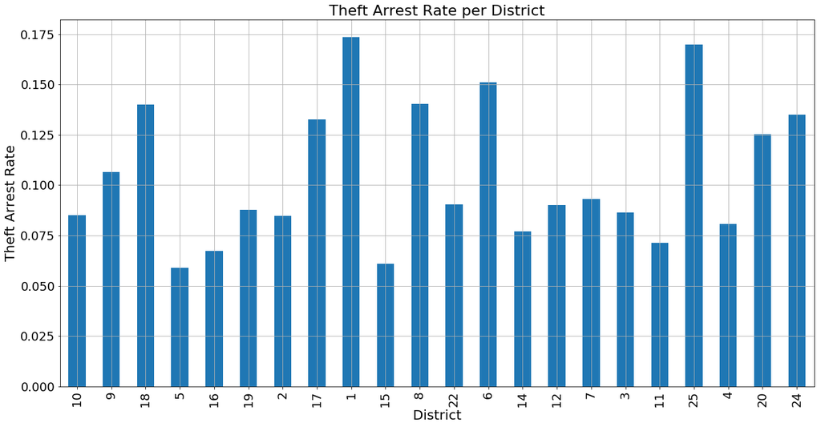

```python
thefts = dist_pred_arrest['Theft Arrest Rate']
theftRate = thefts.plot(kind='bar', grid=True, figsize=(20,10), legend=False, color='tab:blue')
theftRate.set_title('Theft Arrest Rate per District', fontsize=22)
theftRate.set_xlabel('District', fontsize=20)
theftRate.set_ylabel('Theft Arrest Rate', fontsize=20)
theftRate.tick_params(labelsize=18)
theftRate
```

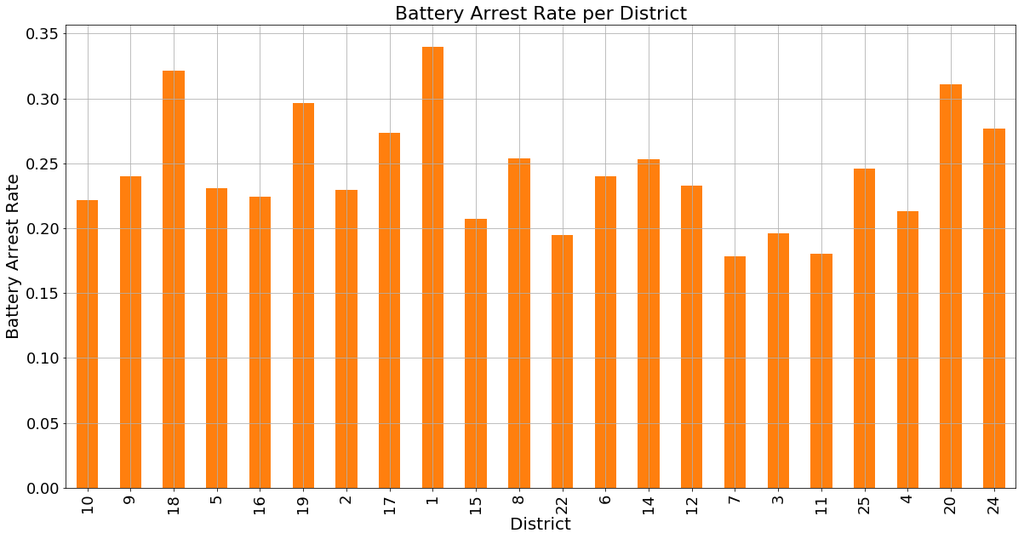

```python
battery = dist_pred_arrest['Battery Arrest Rate']
batteryRate = battery.plot(kind='bar', grid=True, figsize=(20,10), legend=False, color='tab:orange')
batteryRate.set_title('Battery Arrest Rate per District', fontsize=22)
batteryRate.set_xlabel('District', fontsize=20)
batteryRate.set_ylabel('Battery Arrest Rate', fontsize=20)
batteryRate.tick_params(labelsize=18)
batteryRate
```

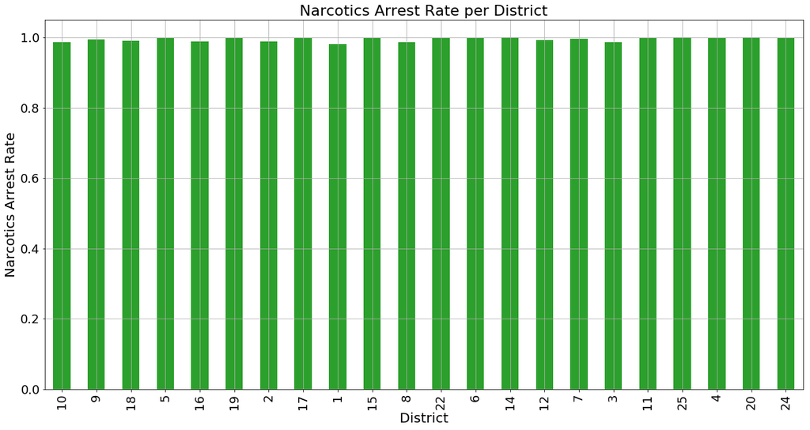

```python
narcotics = dist_pred_arrest['Narcotics Arrest Rate']
narcoticsRate = narcotics.plot(kind='bar', grid=True, figsize=(20,10), legend=False, color='tab:green')
narcoticsRate.set_title('Narcotics Arrest Rate per District', fontsize=22)
narcoticsRate.set_xlabel('District', fontsize=20)
narcoticsRate.set_ylabel('Narcotics Arrest Rate', fontsize=20)
narcoticsRate.tick_params(labelsize=18)
narcoticsRate
```

From these three graphs, we can see how Theft anad Battery arrest ratios vary from district to district, while Narcotics arrest ratios seem to be fairly similar (and quite high) across the districts. Let's now jump into using this data to build a model and come up with an analysis that answers our research question.

# Part 5 - Data Analysis and Results

Our research questions is whether an arrest was made from a reported crime is better predicted by the type of crime commmited or the district in which the crime is committed.

Because the dependent variable, Arrest is a true or false value, we first converted it to a 1 or a 0, with 1 for true and 0 for false.

Because Arrest is binary, we chose a Binomial regression as our data model. Binomial regression/Logistic regression is useful when a dependent variable is binary because it doesn't attempt to fit a line to the data, it produces a curve that represents the chance that an input would results in a true or a false value.

```python
binomial_model = smf.glm(formula='Arrest ~ Type + District', data=crime,family=sm.families.Binomial())
binomial_results = binomial_model.fit()
binomial_results.summary()
```

Generalized Linear Model Regression Results

| Dep. Variable: | Arrest | No. Observations: | 680845 |
| --- | --- | --- | --- |
| Model: | GLM | Df Residuals: | 680795 |
| Model Family: | Binomial | Df Model: | 49 |
| Link Function: | logit | Scale: | 1.0000 |
| Method: | IRLS | Log-Likelihood: | -2.3898e+05 |
| Date: | Mon, 18 Mar 2019 | Deviance: | 4.7795e+05 |
| Time: | 18:23:34 | Pearson chi2: | 6.84e+05 |
| No. Iterations: | 22 | Covariance Type: | nonrobust |

|  | coef | std err | z | P>\|z\| | [0.025 | 0.975] |
| --- | --- | --- | --- | --- | --- | --- |
| Intercept | -1.5564 | 0.106 | -14.690 | 0.000 | -1.764 | -1.349 |
| Type[T.assault] | 0.9820 | 0.105 | 9.333 | 0.000 | 0.776 | 1.188 |
| Type[T.battery] | 0.8854 | 0.105 | 8.448 | 0.000 | 0.680 | 1.091 |
| Type[T.burglary] | -0.7827 | 0.107 | -7.342 | 0.000 | -0.992 | -0.574 |
| Type[T.criminal damage] | -0.4993 | 0.106 | -4.728 | 0.000 | -0.706 | -0.292 |
| Type[T.criminal trespass] | 3.1264 | 0.106 | 29.483 | 0.000 | 2.919 | 3.334 |
| Type[T.deceptive practice] | 0.6621 | 0.106 | 6.262 | 0.000 | 0.455 | 0.869 |
| Type[T.gambling] | 8.3399 | 0.587 | 14.200 | 0.000 | 7.189 | 9.491 |
| Type[T.homicide] | 2.5819 | 0.167 | 15.477 | 0.000 | 2.255 | 2.909 |
| Type[T.interference with public officer] | 4.8266 | 0.134 | 35.932 | 0.000 | 4.563 | 5.090 |
| Type[T.intimidation] | 0.7074 | 0.173 | 4.080 | 0.000 | 0.368 | 1.047 |
| Type[T.kidnapping] | 0.1403 | 0.168 | 0.834 | 0.404 | -0.189 | 0.470 |
| Type[T.liquor law violation] | 6.4843 | 0.289 | 22.474 | 0.000 | 5.919 | 7.050 |
| Type[T.motor vehicle theft] | -0.7877 | 0.107 | -7.337 | 0.000 | -0.998 | -0.577 |
| Type[T.narcotics] | 7.4316 | 0.117 | 63.437 | 0.000 | 7.202 | 7.661 |
| Type[T.non-criminal] | 1.7661 | 0.775 | 2.279 | 0.023 | 0.247 | 3.285 |
| Type[T.obscenity] | 3.4759 | 0.327 | 10.621 | 0.000 | 2.835 | 4.117 |
| Type[T.offense involving children] | 0.6415 | 0.111 | 5.772 | 0.000 | 0.424 | 0.859 |
| Type[T.other] | 0.4889 | 0.105 | 4.636 | 0.000 | 0.282 | 0.696 |
| Type[T.other narcotic violation] | 2.0229 | 0.684 | 2.959 | 0.003 | 0.683 | 3.363 |
| Type[T.prostitution] | 7.4921 | 0.253 | 29.660 | 0.000 | 6.997 | 7.987 |
| Type[T.public indecency] | 25.4535 | 1.52e+04 | 0.002 | 0.999 | -2.98e+04 | 2.99e+04 |
| Type[T.public peace violation] | 3.1881 | 0.108 | 29.389 | 0.000 | 2.975 | 3.401 |
| Type[T.robbery] | -0.1130 | 0.107 | -1.060 | 0.289 | -0.322 | 0.096 |
| Type[T.sex offense] | 1.2711 | 0.115 | 11.096 | 0.000 | 1.047 | 1.496 |
| Type[T.sexual assault] | 0.3934 | 0.117 | 3.367 | 0.001 | 0.164 | 0.622 |
| Type[T.stalking] | 0.5617 | 0.171 | 3.288 | 0.001 | 0.227 | 0.897 |
| Type[T.theft] | -0.0718 | 0.105 | -0.684 | 0.494 | -0.277 | 0.134 |
| Type[T.weapons violation] | 3.6152 | 0.109 | 33.267 | 0.000 | 3.402 | 3.828 |
| District[T.10] | -0.5169 | 0.024 | -21.145 | 0.000 | -0.565 | -0.469 |
| District[T.11] | -0.5524 | 0.023 | -23.830 | 0.000 | -0.598 | -0.507 |
| District[T.12] | -0.5824 | 0.024 | -24.232 | 0.000 | -0.629 | -0.535 |
| District[T.14] | -0.6195 | 0.026 | -23.663 | 0.000 | -0.671 | -0.568 |
| District[T.15] | -0.5738 | 0.025 | -22.573 | 0.000 | -0.624 | -0.524 |
| District[T.16] | -0.8462 | 0.028 | -30.403 | 0.000 | -0.901 | -0.792 |
| District[T.17] | -0.5001 | 0.028 | -18.144 | 0.000 | -0.554 | -0.446 |
| District[T.18] | -0.1625 | 0.023 | -7.090 | 0.000 | -0.207 | -0.118 |
| District[T.19] | -0.4784 | 0.024 | -20.025 | 0.000 | -0.525 | -0.432 |
| District[T.2] | -0.6600 | 0.025 | -26.389 | 0.000 | -0.709 | -0.611 |
| District[T.20] | -0.3527 | 0.032 | -11.012 | 0.000 | -0.416 | -0.290 |
| District[T.22] | -0.7696 | 0.028 | -27.936 | 0.000 | -0.824 | -0.716 |
| District[T.24] | -0.4455 | 0.027 | -16.602 | 0.000 | -0.498 | -0.393 |
| District[T.25] | -0.4190 | 0.023 | -18.553 | 0.000 | -0.463 | -0.375 |
| District[T.3] | -0.6553 | 0.024 | -27.838 | 0.000 | -0.701 | -0.609 |
| District[T.4] | -0.7183 | 0.023 | -31.065 | 0.000 | -0.764 | -0.673 |
| District[T.5] | -0.6269 | 0.024 | -25.611 | 0.000 | -0.675 | -0.579 |
| District[T.6] | -0.4434 | 0.022 | -19.774 | 0.000 | -0.487 | -0.399 |
| District[T.7] | -0.5897 | 0.023 | -25.996 | 0.000 | -0.634 | -0.545 |
| District[T.8] | -0.4281 | 0.022 | -19.667 | 0.000 | -0.471 | -0.385 |
| District[T.9] | -0.3819 | 0.023 | -16.515 | 0.000 | -0.427 | -0.337 |

## Preliminary Analysis

The intercept of the model is an arson committed in district 1. We found this by noticing that district 1 is the only district not included in the summary, and arson is the only crime type not included in the summary.

A higher coefficient in the table above indicates that the associated variable (district or type) is more likely to result in an arrest. A lower coefficient indicates the opposite.

Additionally, we use the common alpha level of 0.05 to determine whether a variable is significant. Any variable with p-value greater than 0.05 is considered insignificant, and any variable with a p-value less than 0.05 is considered significant. For example, we don't consider the type 'Public Indecency' to be significant because it has a p-value very close to 1, even though it has a high coefficient. This is probably because this is a rare crime type, so there isn't enough data for the model to find significance. On the other hand, the vast majority of our variables have a p-value very close to 0, which indicates that most of them are significant in predicting your arrest.

## Looking at the top three crimes

We want to look at the top three crimes overall, because this might give us a more generalized picture of what overall crime looks like in Chicago

```python
crime['Type'].value_counts().nlargest(3)
```

```
theft        152481
battery      118891
narcotics     74629
Name: Type, dtype: int64
```

```python
top_crime = crime[(crime['Type'] == 'theft') | (crime['Type'] == 'battery') | (crime['Type'] == 'narcotics')]
```

```python
binomial_model = smf.glm(formula='Arrest ~ Type + District', data=top_crime,family=sm.families.Binomial())
binomial_results = binomial_model.fit()
binomial_results.summary()
```

Generalized Linear Model Regression Results

| Dep. Variable: | Arrest | No. Observations: | 346001 |
| --- | --- | --- | --- |
| Model: | GLM | Df Residuals: | 345977 |
| Model Family: | Binomial | Df Model: | 23 |
| Link Function: | logit | Scale: | 1.0000 |
| Method: | IRLS | Log-Likelihood: | -1.1847e+05 |
| Date: | Mon, 18 Mar 2019 | Deviance: | 2.3693e+05 |
| Time: | 18:23:49 | Pearson chi2: | 3.51e+05 |
| No. Iterations: | 8 | Covariance Type: | nonrobust |

|  | coef | std err | z | P>\|z\| | [0.025 | 0.975] |
| --- | --- | --- | --- | --- | --- | --- |
| Intercept | -0.5994 | 0.023 | -26.050 | 0.000 | -0.644 | -0.554 |
| Type[T.narcotics] | 6.6094 | 0.053 | 123.772 | 0.000 | 6.505 | 6.714 |
| Type[T.theft] | -0.9908 | 0.011 | -87.774 | 0.000 | -1.013 | -0.969 |
| District[T.10] | -0.7198 | 0.034 | -21.146 | 0.000 | -0.786 | -0.653 |
| District[T.11] | -0.8959 | 0.033 | -27.424 | 0.000 | -0.960 | -0.832 |
| District[T.12] | -0.6608 | 0.033 | -20.282 | 0.000 | -0.725 | -0.597 |
| District[T.14] | -0.6642 | 0.035 | -18.796 | 0.000 | -0.733 | -0.595 |
| District[T.15] | -0.7986 | 0.035 | -22.502 | 0.000 | -0.868 | -0.729 |
| District[T.16] | -0.8198 | 0.040 | -20.723 | 0.000 | -0.897 | -0.742 |
| District[T.17] | -0.3337 | 0.036 | -9.169 | 0.000 | -0.405 | -0.262 |
| District[T.18] | -0.2065 | 0.030 | -6.929 | 0.000 | -0.265 | -0.148 |
| District[T.19] | -0.5406 | 0.032 | -16.870 | 0.000 | -0.603 | -0.478 |
| District[T.2] | -0.6889 | 0.034 | -20.213 | 0.000 | -0.756 | -0.622 |
| District[T.20] | -0.2679 | 0.043 | -6.279 | 0.000 | -0.351 | -0.184 |
| District[T.22] | -0.7718 | 0.038 | -20.059 | 0.000 | -0.847 | -0.696 |
| District[T.24] | -0.3182 | 0.036 | -8.936 | 0.000 | -0.388 | -0.248 |
| District[T.25] | -0.2933 | 0.030 | -9.750 | 0.000 | -0.352 | -0.234 |
| District[T.3] | -0.8161 | 0.033 | -24.663 | 0.000 | -0.881 | -0.751 |
| District[T.4] | -0.7389 | 0.032 | -23.337 | 0.000 | -0.801 | -0.677 |
| District[T.5] | -0.7219 | 0.034 | -21.187 | 0.000 | -0.789 | -0.655 |
| District[T.6] | -0.3943 | 0.030 | -13.060 | 0.000 | -0.453 | -0.335 |
| District[T.7] | -0.8555 | 0.032 | -26.916 | 0.000 | -0.918 | -0.793 |
| District[T.8] | -0.3826 | 0.029 | -12.993 | 0.000 | -0.440 | -0.325 |
| District[T.9] | -0.5525 | 0.032 | -17.080 | 0.000 | -0.616 | -0.489 |

## Analysis Conclusions

Overall, because the average crime type coefficient was larger than the average district coefficient, the type of crime is more predictive than the district. The reason behind this is that if you gave us an arbitrary crime, we would be able to more accurately predict whether you would be arrested or not than if you gave us an arbitrary district. This contradicts our hypothesis, but is useful to know nonetheless.

We also looked at the top three crimes, and found that when looking at only these crimes, the analysis doesn't change much. Narcotics crime is still the most likely crime out of the top three to predict your arrest.

# Part 6 - Privacy/Ethics Considerations

##### Privacy

For the purpose of our analysis, we do have permission to use this dataset becauset the police department released as public record. The data is also fairly private because there is no individual person identifying information. There are no names, only crime ids and description. The only identifying information is the location (partial addresses and longitude/latitude). This could be an issue because some of the crimes occurred in apartments, so you could conceivably find out the location where a crime was committed and use this to find someone. However, for our project purposes, we decided to use district # instead so we simply dropped those other location identifying sections from our data to further perserve the privacy of those involved when we release our findings.

##### Ethics

A potential ethics considerations involving this data is that we are publicizing the locations of high crime, which could be used to discriminate against communities. While this data is publicily available, we are organizing and formatting it in a way that can be used to show which districts have a high crime rate. People with ill intentions could use this to argue that no one should go near these areas, alientating those communities.

# Part 7 - Conclusions and Discussion

##### Our Conclusion

After studying our analysis, we disprove our hypothesis and conclude that district is less predictive of arrest than crime type. We thought that district would be more predictive because different districts would have different types of crime, and have different amounts of police, which would lead to a significant difference in arrests. However, we discovered that the type of crime was more strongly correlated with arrest than the district.

##### Potential Biases

We realize that there are some potential biases in our dataset, because while this data was collected by the police department, there are a lot of crimes that happen where those involved do not go to or report to the police. Unfortunately these instances/crimes would be omitted from the data, which could skew the data to lean towards one or more areas unfairly.

##### Potential Incorrect Data

It's important to note that our data represents reported crimes. We operated with the assumption that no crimes are reported falsely. This was a reasonable assumption on our part because we assumed that the number of real crimes reported is much higher than the number of crimes reported falsely. This does introduce a possible counfounding variable into our dataset, but it was not feasible to account for this in a reasonable amount of time.